# Mazagão

## 3.3 Dados: IBGE

Disonivel para cada municipio.

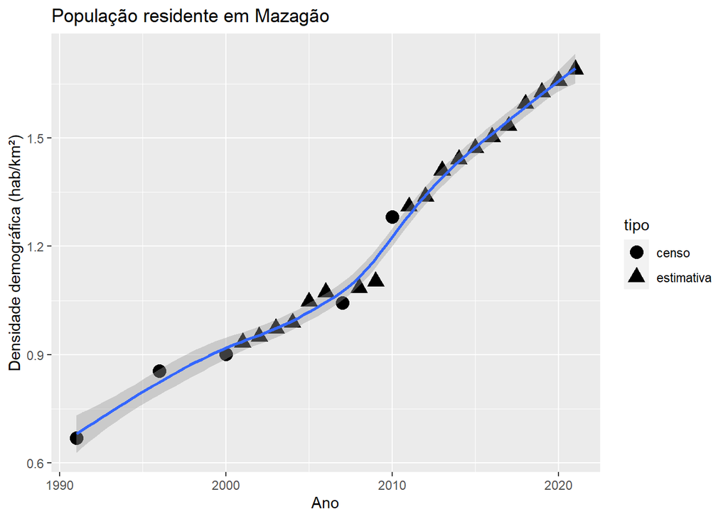

```r
# IBGE
# Geral https://cidades.ibge.gov.br/brasil/ap/mazagao/panorama
# IBGE SIDRA  https://sidra.ibge.gov.br/pesquisa/censo-demografico/series-temporais/series-temporais/
# Censo: Tabela 136; 1996 = Tabela 475; e 2007 = Tabela 793.
censo_pop <- c(8894,    11353, 11986, 13862, 17032)
censo_ano <- c(1991, 1996, 2000, 2007, 2010)
df_censo <- data.frame(tipo = "censo", ano = censo_ano, pop = censo_pop)

# Estimativas anuais IBGE SIDRA Tabela 6579
est_pop <- c(12410, 12633,  12933,  13139,  13913,  14259,  14418,  14655,  17420,  17794,  18739,  19157,  19571,  19981,  20387,  21206,  21632,  22053,  22468)
est_ano <- c(2001,  2002,   2003,   2004,   2005,   2006,   2008,   2009,   2011,   2012,   2013,   2014,   2015,   2016,   2017,   2018,   2019,   2020,   2021)
df_est <- data.frame(tipo = "estimativa", ano = est_ano, pop = est_pop)

# Calcular densidade demográfica
df_pop <- bind_rows(df_censo, df_est) %>%
  mutate(pop_dens_km2 = pop/13294.78) %>% arrange(ano)

# Vizualizar

df_pop %>%
  ggplot(aes(x=ano, y=pop_dens_km2)) +
  geom_point(aes(shape=tipo), size = 4) +
  stat_smooth(method = "gam") +
  labs(title = "População residente em Mazagão",
       y = "Densidade demográfica (hab/km²)",
       x = "Ano")
```

# 4 Métricas da paisagem e pacote “landscapemetrics”

## 4.1 Calculo de métricas

Para ilustrar como rodar as funções e cálculos com landscapemetrics, vamos calcular a área central na paisagem que usamos no tutorial de Escala. Vamos estudar uma classe (floresta), portanto vamos incluir as métricas para nível de classe. Além disso, as métricas de paisagem em nível de classe são mais eficazes na definição de processos ecológicos (Tischendorf, L. Can landscape indices predict ecological processes consistently?. Landscape Ecology 16, 235–254 (2001). https://doi.org/10.1023/A:1011112719782.).

Métricas de área central (“core area”) são consideradas medidas da qualidade de hábitat, uma vez que indica quanto existe realmente de área efetiva de um fragmento, após descontar-se o efeito de borda. Vamos calcular a percentual de área central (“core area”). Isso seria, a percentual de áreas centrais (excluídas as bordas de 30 m) de cada classe em relação à área total da paisagem.

### 4.1.1 Região único, métrica única

Para a função sample_lsm() funcionar, precisamos informar (i) a paisagem (arquivo de raster), (ii) região de interesse (polígono), e por final (v) a métrica desejada.

```r
minha_amostra_250 <- sample_lsm(landscape = floresta_2020,
                                 y = maza_buffers[1, ],
                                 plot_id = data.frame(maza_buffers)[1, 'dist_km'],
                            metric = "cpland",
                            edge_depth = 1)
```

Depois que executar (“run”), podemos olhar os dados com o codigo a seguir.

```r
minha_amostra_250
```

Os dados deve ter os valores (coluna value) da métrica (coluna metric) de cada classe (coluna class):

| layer | level | class | id | metric | value | plot_id | percentage_inside |
| --- | --- | --- | --- | --- | --- | --- | --- |
| 1 | class | 0 | NA | cpland | 46.11872 | 0.25 | 99.66742 |
| 1 | class | 1 | NA | cpland | 9.13242 | 0.25 | 99.66742 |

### 4.1.2 Distâncias variados, métrica única

Aqui no exmplo vamos quantificar a mesma métrica para 8 distancias diferentes. Usando buffer com extensões diferentes de 250, 500, 1000, 2000, 4000, 8000, 16000 e 32000 metros distantes.

```r
# Metricá para as distancias
minha_metrica <- sample_lsm(landscape = floresta_2020,
                                 y = maza_buffers,
                                 plot_id = data.frame(maza_buffers)[, 'dist_km'],
                            metric = "cpland",
                            edge_depth = 1)
```

# 5 Gráficos

Antes de apresentar os resultados, precisamos primeiramente organizar os dados. Os dados de entrada eram no objeto “maza_buffers”, formato vetor (polígonos). O formato de vetor tem uma tabela de atributos e precisamos acrescentar os valores da métrica (no objeto “minha_metrica”) associado com cada polígono (buffer) para apresentar e analisar os resultados.

Escolhendo a classe de floresta através de um filtro e selecionando as colunas desejadas e colocando-as na sequência desejada (“select”), usando a função “left_join” para adicionar as métricas aos buffers.

```r
# Organizar dados
resultados <- maza_buffers %>%
  left_join(minha_metrica %>% dplyr::filter(class==1) %>%
              dplyr::select(plot_id, class, metric, value),
            by=c("dist_km"="plot_id")) %>%
  mutate(value = round(value,2))
```

Agora, usando o codigo a seguir podemos visualizar os resultados em um gráfico……

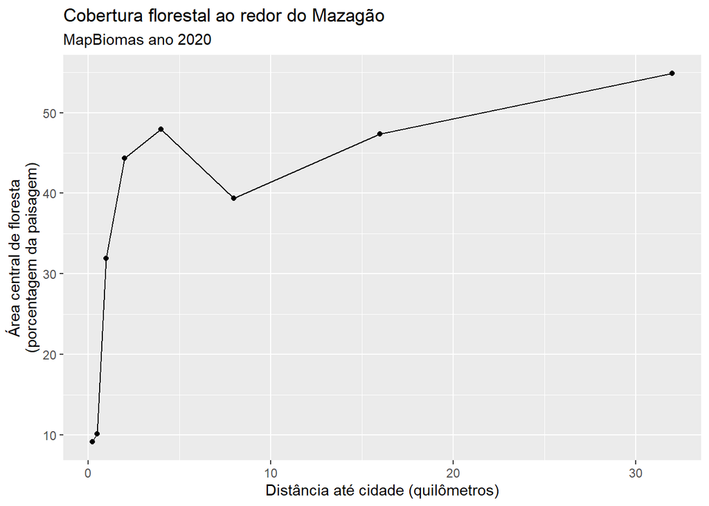

```r
# Gráfico
resultados %>%
ggplot(aes(x=dist_km, y=value)) +
  geom_point() +
  geom_line() +
  labs(title = "Cobertura florestal ao redor do Mazagão",
       subtitle = "MapBiomas ano 2020",
       x = "Distância até cidade (quilômetros)",
       y = "Área central de floresta\n(porcentagem da paisagem)")
```

Além disso, como os resultados ficaram na tabela de atributos podemos também visualizar em um mapa, neste caso um mapa interativa …….

```r
buffer_line <- st_cast(resultados, 'LINESTRING')
```

```r
mapview::mapview(buffer_line, zcol="value", lwd = 8,
                  popup = popupTable(buffer_line,
                                     zcol = c("dist_km",
                                              "metric",
                                              "value"))
                  ) +
mapview::mapview(maza_ponto, col.regions= "black")
```

[interactive chart not shown]

```r
# Objeto com os nomes das funções para calcular as métricas desejadas.
minhas_metricas <- c("lsm_c_cpland",
                     "lsm_c_enn_mn", "lsm_c_enn_sd", "lsm_c_enn_cv",
                     "lsm_c_pd")
# Objeto com o mesmo paisagem em anos diferentes.
floresta_anos <- c(floresta_1985, floresta_2005, floresta_2020)

# Metricás para as distancias
minha_metricas_anos <- sample_lsm(landscape = floresta_anos,
                                 y = maza_buffers,
                                 plot_id = data.frame(maza_buffers)[, 'dist_km'],
                            what = minhas_metricas,
                            edge_depth = 1)


# Organizar dados
resultados_anos <- maza_buffers %>%
  left_join(minha_metricas_anos %>% dplyr::filter(class==1) %>%
              dplyr::mutate(value = round(value,2),
         ano = case_when(layer==1 ~1985,
                         layer==2~2005,
                         layer==3~2020)) %>%
              dplyr::select(ano, plot_id, class, metric, value),
            by=c("dist_km"="plot_id"))
```

Grafico.

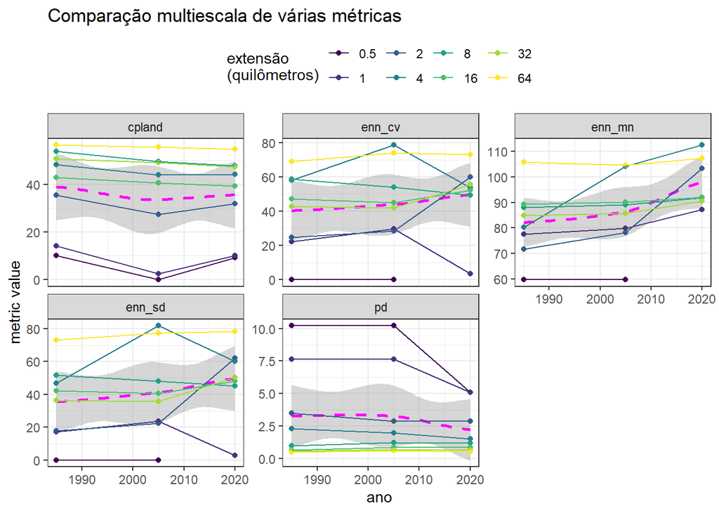

```r
resultados_anos %>%
  mutate(ext_km = (2*dist_km)) %>%
# fazer grafico
  ggplot(aes(x=ano, y=value)) +
  stat_smooth(linetype="dashed", colour = "magenta") +
  geom_point(aes(group=ext_km, colour = factor(ext_km))) +
  geom_line(aes(group=ext_km, colour = factor(ext_km))) +
  scale_color_viridis_d("extensão\n(quilômetros)") +
  facet_wrap(~metric, scales = "free_y") +
  labs(title = "Comparação multiescala de várias métricas",
    x = "ano",
    y = "metric value") +
  theme_bw() + theme(legend.position="top")
```

Gráfico alternativa.

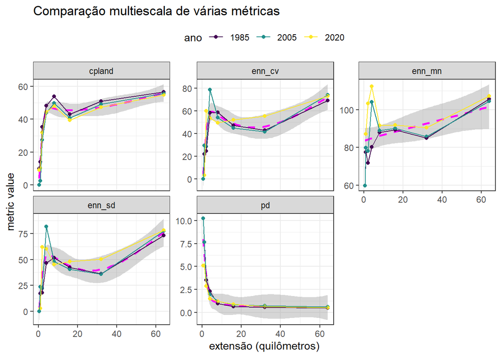

```r
resultados_anos %>%
  mutate(ext_km = (2*dist_km)) %>%
# fazer grafico
  ggplot(aes(x=ext_km, y=value)) +
  stat_smooth(method="gam",
              formula = y ~ s(x, bs = "cs", k=5),
              linetype="dashed", colour = "magenta") +
  geom_point(aes(group=ano, colour = factor(ano))) +
  geom_line(aes(group=ano, colour = factor(ano))) +
  scale_color_viridis_d("ano") +
  facet_wrap(~metric, scales = "free_y") +
  labs(title = "Comparação multiescala de várias métricas",
    x = "extensão (quilômetros)",
    y = "metric value") +
  theme_bw() + theme(legend.position="top")
```